# QTM 151 Final Project

## **QTM 151 Final Project: Human Rights Measurement Iniative**

### Darya Dahi, Elliot Li, Hayden Tupper, Mihir Chathurvedula

### Overview:

- CPR: Civil & Political Rights (e.g., freedom of expression, protection from torture)
- PaR: People at Risk (identifies vulnerable populations per right)
- ESR: Economic & Social Rights (e.g., education, health, housing, work)

Our project aims to explore global, regional, and cross-domain patterns in human rights using HRMI data to identify trends, disparities, and correlations.

#### Setup:

Before we begin, let us import the necessary packages for analysis:

```python
#importing necessary packages
import numpy as np
import matplotlib.pyplot as plt
import pandas as pd
from wordcloud import WordCloud
import re
import seaborn as sns
import os
from tabulate import tabulate
```

#### **Insight 1: Quality of Life — Are We Better Off?**

In the modern age, we are constantly innovating and optimizing the world in an effort to improve quality of life, but is that progress reflected in the data? To explore this, we analyze income-adjusted Quality of Life (QoL) scores across countries from 2017 to 2021, with LMY meaning Low & Medium-Income Countries and HMY being High Income Countries.

First let us explore both datasets and clean them up.

```python
# Rename columns for better readability
esr_lmy = esr_lmy.rename(columns={
    "AdultSurvival_All_IAFrontier": "Adult Survival Frontier",
    "AdultSurvival_All_IAPenalty": "Adult Survival Penalty",
    "AdultSurvival_All_IAScore": "Adult Survival Score",
    "AdultSurvival_All_MRGDP": "Adult Survival GDP",
    "AdultSurvival_All_MRValue": "Adult Survival Value",
    "AdultSurvival_All_MRYear": "Adult Survival Year",
    "AffordHouse_IAFrontier": "Affordable Housing Frontier",
    "AffordHouse_IAPenalty": "Affordable Housing Penalty",
    "AffordHouse_IAScore": "Affordable Housing Score",
    # Add similar mappings for all other columns in esr_lmy
})

esr_hiy = esr_hiy.rename(columns={
    "HiY_Education_All_IAScore": "High-Income Education Score",
    "HiY_Food_All_IAScore": "High-Income Food Score",
    "HiY_Health_All_IAScore": "High-Income Health Score",
    "HiY_Housing_All_IAScore": "High-Income Housing Score",
    "HiY_QofL_All_IAScore": "High-Income Quality of Life Score",
    # Add similar mappings for all other columns in esr_hiy
})

# Summary statistics for key columns
summary_stats_lmy = esr_lmy.describe().round(2)
summary_stats_hiy = esr_hiy.describe().round(2)

# Print summary statistics
print("\nSummary Statistics for LMY:")
print(tabulate(summary_stats_lmy, headers='keys', tablefmt='fancy_grid'))
print("\nSummary Statistics for HiY:")
print(tabulate(summary_stats_hiy, headers='keys', tablefmt='fancy_grid'))
```

```
Summary Statistics for LMY:
╒═══════╤═══════════════════════╤═════════╤════════════════════════╤═════════════════════════════╤════════════════════════╤══════════════════════════╤═══════════════════════════╤════════════════════════╤═════════════════════════╤════════════════════════╤═════════════════════════════╤════════════════…
│       │   High_Income_Country │    Year │   LMY_QofL_All_IAScore │   LMY_Education_All_IAScore │   LMY_Food_All_IAScore │   LMY_Health_All_IAScore │   LMY_Housing_All_IAScore │   LMY_Work_All_IAScore │   H_EducQual_All_MRYear │   H_EducQual_All_MRGDP │   H_EducQual_All_IAFrontier │   H_EducQual_Al…
╞═══════╪═══════════════════════╪═════════╪════════════════════════╪═════════════════════════════╪════════════════════════╪══════════════════════════╪═══════════════════════════╪════════════════════════╪═════════════════════════╪════════════════════════╪═════════════════════════════╪════════════════…
│ count │               7104    │ 7104    │                 768    │                     1362    │                3518    │                  4040    │                   4142    │                3834    │                 1578    │                1578    │                     1578    │                …
├───────┼───────────────────────┼─────────┼────────────────────────┼─────────────────────────────┼────────────────────────┼──────────────────────────┼───────────────────────────┼────────────────────────┼─────────────────────────┼────────────────────────┼─────────────────────────────┼────────────────…
│ mean  │                  0.37 │ 2005.5  │                  75.12 │                       75.84 │                  72.67 │                    74.43 │                     74.39 │                  74.19 │                 2014.54 │               23492.2  │                      513.59 │                …
├───────┼───────────────────────┼─────────┼────────────────────────┼─────────────────────────────┼────────────────────────┼──────────────────────────┼───────────────────────────┼────────────────────────┼─────────────────────────┼────────────────────────┼─────────────────────────────┼────────────────…
│ std   │                  0.48 │    9.23 │                  13.45 │                       12.92 │                  18.59 │                    13.41 │                     24.64 │                  25.86 │                    4.4  │               22541.3  │                       51.69 │                …
├───────┼───────────────────────┼─────────┼────────────────────────┼─────────────────────────────┼────────────────────────┼──────────────────────────┼───────────────────────────┼────────────────────────┼─────────────────────────┼────────────────────────┼─────────────────────────────┼────────────────…
│ min   │                  0    │ 1990    │                  46.78 │                       29.81 │                   0.7  │                    14.85 │                      7.82 │                   6.52 │                 2010    │                 711.36 │                      383.54 │                …
├───────┼───────────────────────┼─────────┼────────────────────────┼─────────────────────────────┼────────────────────────┼──────────────────────────┼───────────────────────────┼────────────────────────┼─────────────────────────┼────────────────────────┼─────────────────────────────┼────────────────…
│ 25%   │                  0    │ 1997.75 │                  63.16 │                       67.01 │                  60.8  │                    66.58 │                     59.6  │                  54.06 │                 2010    │                6295.55 │                      480.33 │                …
├───────┼───────────────────────┼─────────┼────────────────────────┼─────────────────────────────┼────────────────────────┼──────────────────────────┼───────────────────────────┼────────────────────────┼─────────────────────────┼────────────────────────┼─────────────────────────────┼────────────────…
│ 50%   │                  0    │ 2005.5  │                  79.08 │                       77.19 │                  74.03 │                    76.42 │                     82.94 │                  82.1  │                 2017    │               15116.7  │                      526.4  │                …
├───────┼───────────────────────┼─────────┼────────────────────────┼─────────────────────────────┼────────────────────────┼──────────────────────────┼───────────────────────────┼────────────────────────┼─────────────────────────┼────────────────────────┼─────────────────────────────┼────────────────…
│ 75%   │                  1    │ 2013.25 │                  85.99 │                       86.34 │                  87.91 │                    84.11 │                     94.86 │                  97.9  │                 2018    │               36051.4  │                      557.44 │                …
├───────┼───────────────────────┼─────────┼────────────────────────┼─────────────────────────────┼────────────────────────┼──────────────────────────┼───────────────────────────┼────────────────────────┼─────────────────────────┼────────────────────────┼─────────────────────────────┼────────────────…
```

[output cut: 23 more lines]

From these summary statistics we see:

- QoL is rising—but unevenly: LMY and HiY average scores are close (75 vs. 79), but LMY shows much wider variation.
- Inconsistency in LMY: High spread in LMY housing and work scores signals uneven development.
- HiY is more stable: Low variability across domains reflects strong infrastructure in HiY regions.

So—if the average quality of life is improving, is that improvement shared equally? Let’s look at the trends over time.

First we filter quality of life (QoL) scores for low/middle- and high-income countries, and compute the yearly averages from 2017 onward, and removes any rows with missing data.

```python
# Select the columns for year and QoL score, dropping rows with missing data
lmy_qofl = esr_lmy[["Year", "LMY_QofL_All_IAScore"]].dropna()
hiy_qofl = esr_hiy[["Year", "HiY_QofL_All_IAScore"]].dropna()

# Calculate the average QoL score per year for each group
lmy_avg = lmy_qofl.groupby("Year").mean().reset_index()
hiy_avg = hiy_qofl.groupby("Year").mean().reset_index()

#Filter to focus on years from 2017 to 2023
lmy_avg_filtered = lmy_avg[lmy_avg["Year"] >= 2017]
hiy_avg_filtered = hiy_avg[hiy_avg["Year"] >= 2017]
```

Now, we plot the two!

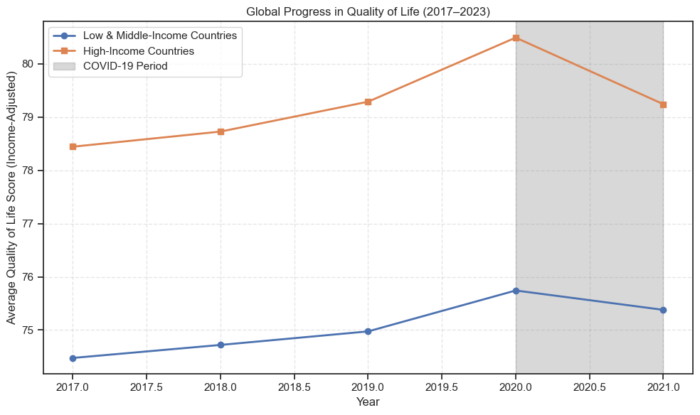

```python
plt.figure(figsize=(10, 6))

# Plot average QoL scores over time
plt.plot(lmy_avg_filtered["Year"], lmy_avg_filtered["LMY_QofL_All_IAScore"],
         label="Low & Middle-Income Countries", marker='o', linewidth=2)

plt.plot(hiy_avg_filtered["Year"], hiy_avg_filtered["HiY_QofL_All_IAScore"],
         label="High-Income Countries", marker='s', linewidth=2)

# Highlight COVID-19 period
plt.axvspan(2020, 2021, color='gray', alpha=0.3, label="COVID-19 Period")

# Labels and title
plt.xlabel("Year")
plt.ylabel("Average Quality of Life Score (Income-Adjusted)")
plt.title("Global Progress in Quality of Life (2017–2023)")
plt.legend()
plt.grid(True, linestyle='--', alpha=0.5)
plt.tight_layout()
plt.show()
```

This graph shows changes in average Quality of Life scores from 2017 to 2021, comparing high-income countries (HiY) (orange line) with low and middle-income countries (LMY) (blue line). The shaded area marks the COVID-19 period, during which quality of life declined, particularly in high-income countries.

Both groups improved steadily until 2020, but saw a drop in 2021—likely due to global challenges like the pandemic. HiY countries consistently had higher scores, while LMY countries made smaller but steady gains.

This suggests that while the world has made progress in quality of life, it hasn’t been equal across income groups. To better understand these changes, we’ll now look at annual growth rates to see how fast QoL is improving and whether lower-income countries are catching up.

```python
lmy_avg_filtered = lmy_avg[lmy_avg["Year"] >= 2017].copy()
hiy_avg_filtered = hiy_avg[hiy_avg["Year"] >= 2017].copy()

lmy_avg_filtered["GrowthRate"] = lmy_avg_filtered["LMY_QofL_All_IAScore"].pct_change() * 100
hiy_avg_filtered["GrowthRate"] = hiy_avg_filtered["HiY_QofL_All_IAScore"].pct_change() * 100

growth_table = pd.DataFrame({
    "Year": lmy_avg_filtered["Year"].values,
    "Low & Middle-Income (LMY) QoL Score": lmy_avg_filtered["LMY_QofL_All_IAScore"].values,
    "Low & Middle-Income (LMY) (%)": lmy_avg_filtered["GrowthRate"].values,
    "High-Income QoL Score (HiY)": hiy_avg_filtered["HiY_QofL_All_IAScore"].values,
    "High-Income YoY Growth (HiY) (%)": hiy_avg_filtered["GrowthRate"].values
})

print(tabulate(growth_table, headers='keys', tablefmt='grid'))
```

```
+----+--------+---------------------------------------+---------------------------------+-------------------------------+------------------------------------+
|    |   Year |   Low & Middle-Income (LMY) QoL Score |   Low & Middle-Income (LMY) (%) |   High-Income QoL Score (HiY) |   High-Income YoY Growth (HiY) (%) |
+====+========+=======================================+=================================+===============================+====================================+
|  0 |   2017 |                               74.4759 |                      nan        |                       78.4443 |                         nan        |
+----+--------+---------------------------------------+---------------------------------+-------------------------------+------------------------------------+
|  1 |   2018 |                               74.7205 |                        0.328349 |                       78.7281 |                           0.361834 |
+----+--------+---------------------------------------+---------------------------------+-------------------------------+------------------------------------+
|  2 |   2019 |                               74.9746 |                        0.340066 |                       79.2894 |                           0.713004 |
+----+--------+---------------------------------------+---------------------------------+-------------------------------+------------------------------------+
|  3 |   2020 |                               75.7432 |                        1.02516  |                       80.4933 |                           1.51828  |
+----+--------+---------------------------------------+---------------------------------+-------------------------------+------------------------------------+
|  4 |   2021 |                               75.3794 |                       -0.480277 |                       79.2431 |                          -1.55318  |
+----+--------+---------------------------------------+---------------------------------+-------------------------------+------------------------------------+
```

This table shows the year-over-year changes in Quality of Life (QoL) scores for Low & Middle-Income (LMY) and High-Income (HiY) countries from 2017 to 2021. Both groups saw steady improvements from 2017 to 2020, with the most significant increase in 2020—LMY QoL rose by about 1.0% and HiY by 1.5%. However, in 2021, both groups experienced a decline: LMY dropped by 0.48% and HiY by 1.55%.

Overall, the data suggests that global QoL improved gradually until 2020, but progress stalled or reversed slightly in 2021, likely reflecting the impact of global disruptions such as the COVID-19 pandemic.

#### Insight 1 Conclusion:

The graph and growth rate table show that global quality of life improved steadily from 2017 to 2020 for both high-income and low- and middle-income countries, with high-income countries maintaining a lead and posting stronger gains. However, both groups saw a decline in 2021—especially high-income countries—highlighting how progress can reverse during global disruptions like the COVID-19 pandemic.

Low- and middle-income countries made consistent but smaller improvements, suggesting slower catch-up due to structural or resource limitations. Overall, while the world is progressing in quality of life, the gains are uneven and vulnerable, emphasizing the need for sustained investment and resilience-building, especially in lower-income regions.

#### **Insight 2: Latin America & Empowerment**

Latin America presents a complex landscape of political freedom and state repression. While some countries exhibit strong civic participation, others grapple with systemic violence and suppression. This raises a key question: Is there a relationship between civic empowerment and state violence—does greater empowerment shield against state repression?

First let us explore the data:

```python
# Load dataset
df_cpr = pd.read_csv(r'C:\Users\chath\Downloads\HRMI_Data_Download_2024_release\HRMI_Data_Download_2024_release\HRMI_Data_Download_2024.6.20\data\cpr.csv')

# List of Latin American countries
latin_america = [
    'Argentina', 'Belize', 'Bolivia', 'Brazil', 'Chile', 'Colombia', 'Costa Rica',
    'Cuba', 'Dominican Republic', 'Ecuador', 'El Salvador', 'Guatemala',
    'Honduras', 'Mexico', 'Nicaragua', 'Panama', 'Paraguay', 'Peru',
    'Uruguay', 'Venezuela', 'Guyana', 'Suriname'
]

# Filter Latin America data
df_latam = df_cpr[df_cpr['country'].isin(latin_america)]

# Create a copy for just the relevant variables and rename for clarity
df_display = df_latam[[
    'empower_mean', 'physint_mean',
    'disap_mean', 'exkill_mean', 'rel_mean'
]].rename(columns={
    'empower_mean': 'Empowerment (Freedom)',
    'physint_mean': 'Physical Integrity (Safety)',
    'disap_mean': 'Disappearances by Authorities',
    'exkill_mean': 'Killings by Authorities',
    'rel_mean': 'Level of Government Repression'
})

# Generate summary statistics
summary_stats = df_display.describe().round(2)

# Print using tabulate for clean formatting
print(tabulate(summary_stats, headers='keys', tablefmt='fancy_grid'))
```

```
╒═══════╤═════════════════════════╤═══════════════════════════════╤═════════════════════════════════╤═══════════════════════════╤══════════════════════════════════╕
│       │   Empowerment (Freedom) │   Physical Integrity (Safety) │   Disappearances by Authorities │   Killings by Authorities │   Level of Government Repression │
╞═══════╪═════════════════════════╪═══════════════════════════════╪═════════════════════════════════╪═══════════════════════════╪══════════════════════════════════╡
│ count │                   21    │                         21    │                           21    │                     21    │                             6    │
├───────┼─────────────────────────┼───────────────────────────────┼─────────────────────────────────┼───────────────────────────┼──────────────────────────────────┤
│ mean  │                    4.3  │                          3.1  │                            4.63 │                      4.37 │                             8.02 │
├───────┼─────────────────────────┼───────────────────────────────┼─────────────────────────────────┼───────────────────────────┼──────────────────────────────────┤
│ std   │                    1.4  │                          0.59 │                            0.89 │                      0.72 │                             1.73 │
├───────┼─────────────────────────┼───────────────────────────────┼─────────────────────────────────┼───────────────────────────┼──────────────────────────────────┤
│ min   │                    1.86 │                          1.82 │                            2.8  │                      3.29 │                             6.17 │
├───────┼─────────────────────────┼───────────────────────────────┼─────────────────────────────────┼───────────────────────────┼──────────────────────────────────┤
│ 25%   │                    2.83 │                          2.74 │                            4.22 │                      3.83 │                             6.5  │
├───────┼─────────────────────────┼───────────────────────────────┼─────────────────────────────────┼───────────────────────────┼──────────────────────────────────┤
│ 50%   │                    4.76 │                          3.29 │                            4.71 │                      4.41 │                             8.04 │
├───────┼─────────────────────────┼───────────────────────────────┼─────────────────────────────────┼───────────────────────────┼──────────────────────────────────┤
│ 75%   │                    5.31 │                          3.48 │                            5.28 │                      4.89 │                             9.62 │
├───────┼─────────────────────────┼───────────────────────────────┼─────────────────────────────────┼───────────────────────────┼──────────────────────────────────┤
│ max   │                    6.93 │                          3.95 │                            5.89 │                      5.6  │                             9.75 │
╘═══════╧═════════════════════════╧═══════════════════════════════╧═════════════════════════════════╧═══════════════════════════╧══════════════════════════════════╛
```

The summary statistics reveal substantial variation across countries. Empowerment scores—which measure people's ability to participate in political life—range from 1.86 to 6.93. Similarly, indicators of state-led violence, such as disappearances and extrajudicial killings, vary significantly across the region. These contrasts raise a key question:

To what extent is political empowerment associated with lower levels of repression and violence by the state in Latin America?

To explore this, we use a correlation heatmap to examine how five core rights indicators relate to one another, followed by a bar plot comparing empowerment levels across countries.

#### Heatmap Analysis of Rights and Repression Across Latin America

The heatmap shows how key human rights indicators are correlated across Latin American countries. We focus on:

- Empowerment (Freedom): People’s ability to vote, protest, and organize
- Physical Integrity (Safety): Protection from torture, detention, and abuse
- Disappearances and Killings by Authorities: Frequency of state-perpetrated violence
- Government Repression: Overall use of force and restrictions on civil liberties
- These indicators help us assess how open or repressive each country’s political environment is.

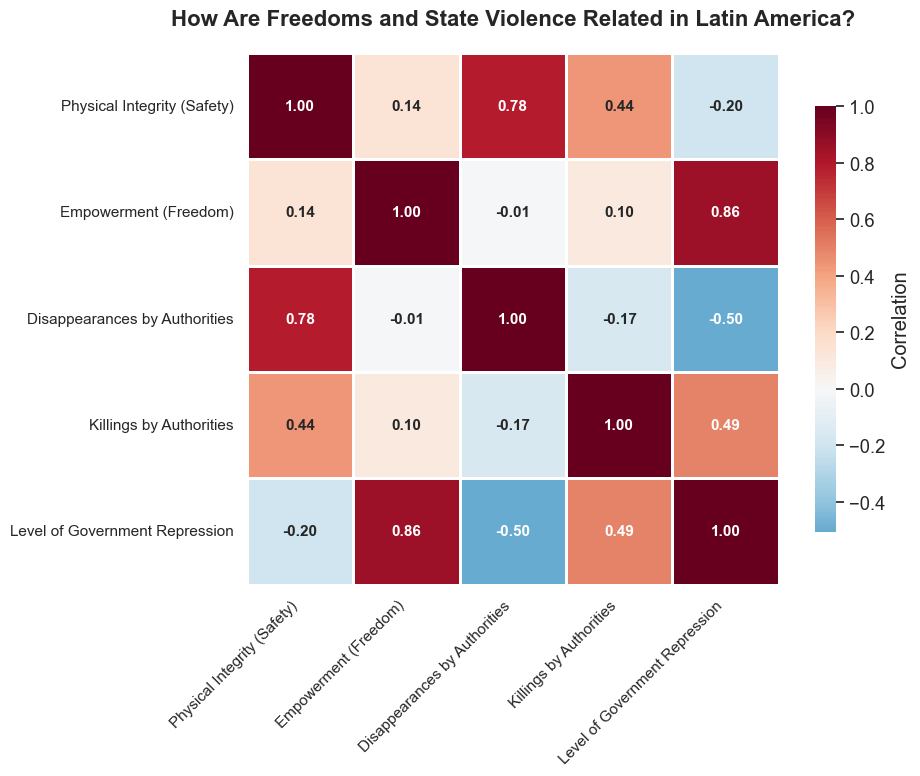

```python
#Variable names for the columns of interest
cols_of_interest = [
    'Physical Integrity (Safety)',
    'Empowerment (Freedom)',
    'Disappearances by Authorities',
    'Killings by Authorities',
    'Level of Government Repression'
]

# Compute correlation matrix
corr = df_display[cols_of_interest].corr()

# Plot aesthetics
sns.set_theme(style="white", font_scale=1.2)
plt.figure(figsize=(10, 8))

# Heatmap plot
heatmap = sns.heatmap(
    corr,
    annot=True,
    fmt=".2f",
    cmap="RdBu_r",
    center=0,
    linewidths=0.75,
    cbar_kws={"shrink": 0.8, "label": "Correlation"},
    annot_kws={"fontsize": 11, "weight": "semibold"},
    square=True
)

# Title and styling
plt.title("How Are Freedoms and State Violence Related in Latin America?", fontsize=16, weight='bold', pad=20)
plt.xticks(rotation=45, ha='right', fontsize=11)
plt.yticks(rotation=0, fontsize=11)
plt.tight_layout()
plt.show()
```

The heatmap shows correlations (r) between empowerment and state violence indicators. Correlation (r) values range from -1 (strong negative relationship) to 1 (strong positive relationship), with 0 meaning no relationship. Darker colors indicate stronger relationships.

While the heatmap shows these broad relationships between rights, it doesn’t tell us which countries are most affected. To complete the picture, we now turn to a comparison of empowerment levels across individual Latin American countries—highlighting where political freedoms are strongest and where they may be at greatest risk.

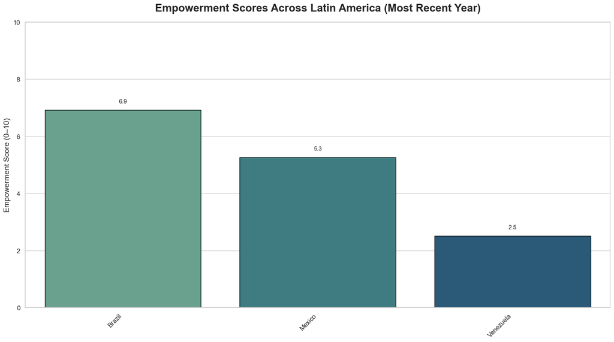

```python
# Filter the dataset for Latin America
# List of Latin American countries
df_latam = df_cpr[df_cpr['country'].isin(latin_america)]

# Keep most recent year per country
df_latest = df_latam.sort_values('year').drop_duplicates('country', keep='last')
df_sorted = df_latest.sort_values('empower_mean', ascending=False)

# Set up the figure and color palette
sns.set_theme(style="whitegrid")
plt.figure(figsize=(16, 9))
bar_palette = sns.color_palette("crest", len(df_sorted))

# Barplot
bar = sns.barplot(
    data=df_sorted,
    x='country',
    y='empower_mean',
    palette=bar_palette,
    edgecolor='black'
)


plt.title('Empowerment Scores Across Latin America (Most Recent Year)', fontsize=20, weight='bold', pad=20)
plt.ylabel('Empowerment Score (0–10)', fontsize=14)
plt.xlabel('')
plt.xticks(rotation=45, ha='right', fontsize=12)
plt.yticks(fontsize=12)
plt.ylim(0, 10)


for p in bar.patches:
    height = p.get_height()
    bar.annotate(f'{height:.1f}',
                 (p.get_x() + p.get_width() / 2, height + 0.2),
                 ha='center', va='bottom', fontsize=11, fontweight='medium')


bar.yaxis.grid(True)
bar.xaxis.grid(False)

plt.tight_layout()
plt.show()
```

#### **Insight 3: Do Strong Civil and Political Rights Go Hand-in-Hand with Economic and Social Rights?**

Civil and political rights are often viewed as foundational to broader human development, but are they accompanied by strong economic and social outcomes? This raises a critical question: Do Strong Civil and Political Rights Go Hand-in-Hand with Economic and Social Rights?

Here, we are exploring the same ESR (Economic and Social Rights) and CPR (Civil and Political Rights) datasets from before, but this time we are looking at the specific relationship between the ESR and CSR scores.

First, let us prepare the datasets for analysis and merge them together.

```python
#Load datasets
esr = pd.read_csv('esr_lmy_globalbest.csv')
cpr = pd.read_csv('cpr.csv')

# Use most recent shared year
latest_year = min(esr['Year'].max(), cpr['year'].max())
esr_latest = esr[esr['Year'] == latest_year]
cpr_latest = cpr[cpr['year'] == latest_year]

# Prepare datasets
esr_trimmed = esr_latest[['Country', 'LMY_QofL_All_GBScore']].rename(columns={
    'Country': 'country', 'LMY_QofL_All_GBScore': 'score_esr'
})

cpr_trimmed = cpr_latest[['country', 'empower_mean']].rename(columns={
    'empower_mean': 'score_cpr'
})

# Merge on country
merged = pd.merge(esr_trimmed, cpr_trimmed, on='country')
```

We then plotted a scatterplot of ESR vs. CPR scores to visually examine the relationship between these two types of rights.

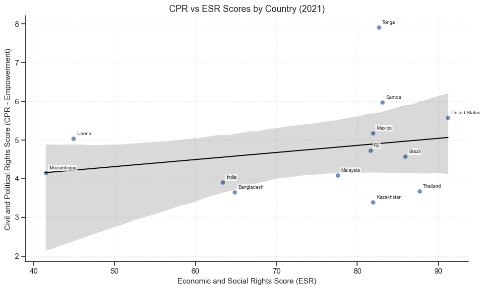

```python
sns.set(style='ticks', context='notebook')
plt.figure(figsize=(10, 6))

# Scatter + regression line
sns.regplot(
    x='score_esr',
    y='score_cpr',
    data=merged,
    scatter_kws={'alpha': 0.8, 's': 50, 'edgecolor': 'white'},
    line_kws={'color': 'black', 'linewidth': 1.5}
)

# Annotate only outliers, slightly offset from point
for _, row in merged.iterrows():
    if abs(row['score_esr'] - row['score_cpr']) > 0.2:
        plt.annotate(
            row['country'],
            xy=(row['score_esr'], row['score_cpr']),
            xytext=(5, 5),
            textcoords='offset points',
            fontsize=7,
            bbox=dict(boxstyle="round,pad=0.2", fc="white", ec="none", alpha=0.7)
        )

# Axis labels and title
plt.xlabel('Economic and Social Rights Score (ESR)', fontsize=11)
plt.ylabel('Civil and Political Rights Score (CPR - Empowerment)', fontsize=11)
plt.title(f'CPR vs ESR Scores by Country ({latest_year})', fontsize=13)

# Grid and layout
sns.despine()
plt.grid(True, linestyle='--', alpha=0.3)
plt.tight_layout()
plt.show()
```

The scatterplot shows a weak positive link between Economic (ESR) and Political (CPR) rights. The black line shows the trend; the grey area is the confidence range. Each point represents a country

The scatterplot reveals that while many countries perform similarly on both ESR and CPR, several stand out with significant imbalances. Some countries rank high in economic and social rights but low in political empowerment, while others have more political freedom than social support. This highlights that the two types of rights can progress independently, depending on a country’s political system or development model.

To support this interpretation, we calculated the correlation between the two scores:

```python
correlation = merged['score_esr'].corr(merged['score_cpr'])
print(f"Correlation between ESR and CPR (Empowerment) scores: {correlation:.2f}")
```

```
Correlation between ESR and CPR (Empowerment) scores: 0.24
```

The result, a correlation of 0.24, suggests a weak positive relationship. This means that while there is some tendency for countries to perform similarly across both rights categories, the link is not strong. In other words, it’s common for a country to be good in one area but not the other.

#### Insight 3 Conlusion:

In conclusion, this analysis shows that civil and political rights do not necessarily align with economic and social rights. Countries should not assume that success in one domain ensures success in the other. A holistic human rights approach must focus on both freedom and well-being to achieve meaningful progress.

### **Conclusion**

Through our data driven analysis of the HRMI dataset, our findings can be summarized as follows:

Although we have made progress in improving human rights accross the globe, there is still a large amount of progress to be made, and data can help us do that.